# Running programs from the command line

*Introduction to Bioinformatics - Module 2*

Nina Norgren

## Programs

- All commands so far are technically programs on their own.
- **ls, cat, head, etc**
- Other programs can also be installed and run from the command line
  - **inkscape**
  - **vlc**
  - **htop**

## What is a Package Manager?

- A tool that simplifies the process of installing, updating, configuring, and removing software on your computer.

**Why Use a Package Manager?**

*Efficiency*: automate handling of software packages, no manual installations and updates  
*Dependency Resolution*: manage dependencies

## Package Management on Debian based systems (linux)

- APT (Advanced Package Tool) is a package management system used in Debian-based distributions

## Package Management on Debian based systems (linux)

- **sudo apt install** - Install a specific package

```
sudo apt install firefox
```

**sudo**: grants permission to make changes on your computer. Ensures necessary authority to modify system settings and files. Requires your password

## Package Management on macOS

- On macOS, Homebrew is a popular package manager
- **Homebrew** simplifies the installation of software on macOS

## Installing Homebrew

- To install Homebrew, open Terminal and run the following command:

```
/bin/bash -c "$(curl -fsSL https://raw.githubusercontent.com/Homebrew/install/HEAD/install.sh)"
```

## Installing Packages with Homebrew

Once Homebrew is installed, you can use it to install packages

```
brew install bcftools
brew install tabix
```

Homebrew will handle dependencies and set up the programs for you

## Running programs

- What does a certain program do?

```
man unzip
```

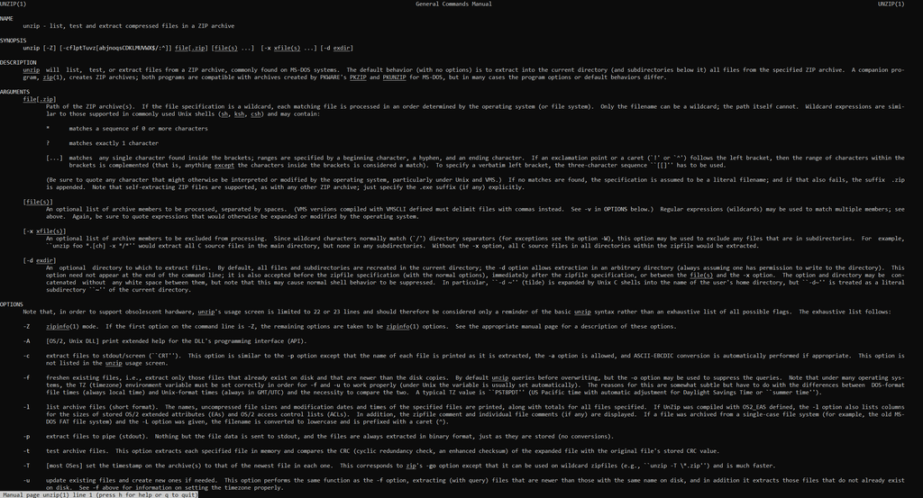

## Running programs

- What does a certain program do?

```
man unzip
```

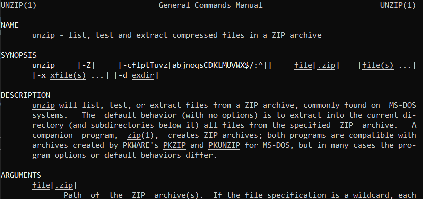

## Running programs

- What command line options does the program have?

```
unzip -h
```

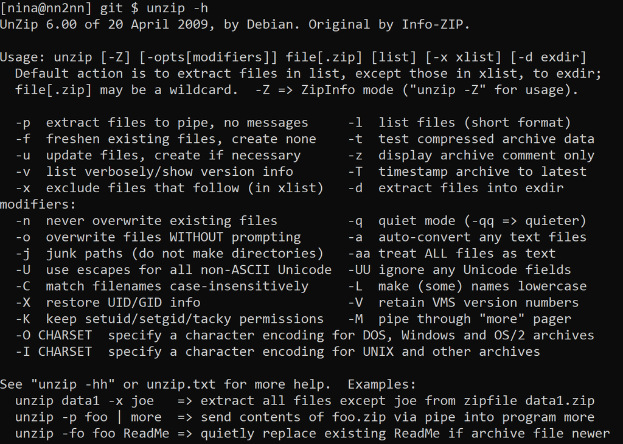

## Running programs

- What command line options does the program have?

```
unzip -h
```

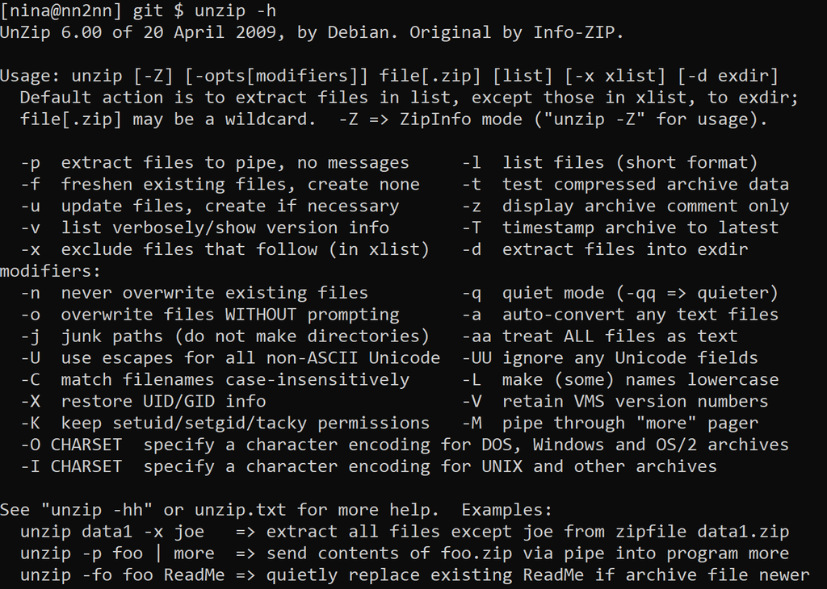

Use command line option **-h**

## Running programs

- Using command line options

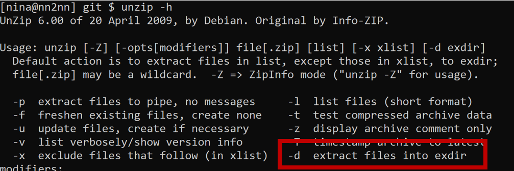

```
unzip my_compressed_files.zip -d my_files/
```